# Statistical Natural Languane Processing

## Homework 1 report

### 96131044

# Part 1

Each document can be represented by the set of words that appear in it.  
But some words are more important and has more effect for determination of the context of the document.  
So we want to represent a document by a set of important words. In this part, we are going to find a set of 100 words that are more infomative for **document classification**.

## Data Set

The dataset for this task is "همشهری" (Hamshahri) that contains 8600 persian documents.

## Preproceesing

We did some preprocessing for building our data structures for processing.  
We read each document and added its words to our vocabulary set and also a set for that document.  
We then used this set to create a vocab_index dictionary for assigning an index for each word that appears in our dataset.  
Our dataset consists of 5 different classes.

```python
import matplotlib.pyplot as plt
import numpy as np
import pandas as pd
import nltk
import sys
```

```python
vocab = set()
doc_vocab = []
number_of_terms = 0
number_of_docs = 0
class_dictionary = {}
cls_index = 0
doc_clss_index = []
count_of_that_class = []
class_name=[]

with open('data.txt', 'r', encoding="utf8") as infile:
    for line in infile:
        number_of_docs +=1
        cls, sep, text = line.partition('@@@@@@@@@@')
        #assigning class index for each document
        if (class_dictionary.get(cls))==None:
            class_dictionary[cls]=cls_index
            tmp = cls_index
            cls_index+=1
            count_of_that_class.append(1)
            class_name.append(cls)

        else:
            tmp = class_dictionary[cls]
            count_of_that_class[tmp] +=1
        doc_clss_index.append(tmp)
        tokens= nltk.word_tokenize(text)
        tmp_set = set()
        number_of_terms += len(tokens)
        for word in tokens:
            vocab.add(word)
            tmp_set.add(word)
        doc_vocab.append(tmp_set)
```

```python
class_name
```

```
['ورزش', 'اقتصاد', 'ادب و هنر', 'اجتماعی', 'سیاسی']
```

There is some statistcs information about out dataset.

```python
print("vocab size:", len(vocab))
print ("number of terms (all tokens):", number_of_terms)
print ("number of docs:", number_of_docs)
print ("number of classes:", cls_index)
```

```
vocab size: 65880
number of terms (all tokens): 3506727
number of docs: 8600
number of classes: 5
```

```python
vocab_size = len(vocab)
number_of_classes = cls_index
count_of_that_class = np.asarray(count_of_that_class)
probability_of_classess = count_of_that_class / number_of_docs
```

The probability of each classes are stored in the table below.

```python
tmp_view = pd.DataFrame(probability_of_classess)
tmp_view
```

|  | 0 |
| --- | --- |
| 0 | 0.232558 |
| 1 | 0.255814 |
| 2 | 0.058140 |
| 3 | 0.209302 |
| 4 | 0.244186 |

```python
word_occurance_frequency = np.zeros(vocab_size, dtype=int)
word_occurance_frequency_vs_class = np.zeros((vocab_size, number_of_classes), dtype=int)
```

```python
word_index = {}
counter = -1
vocab_list = []
for word in vocab:
    counter+=1
    word_index[word]=counter
    vocab_list.append(word)
vocab_list = np.asarray(vocab_list)
```

```python
for i in range(0, number_of_docs):
    for word in doc_vocab[i]:
        index = word_index[word]
        word_occurance_frequency[index]+=1
        word_occurance_frequency_vs_class[index][doc_clss_index[i]] +=1
```

```
calculating probabilities
```

```python
p_w = word_occurance_frequency/number_of_docs
p_w_not = 1 - p_w
p_c = probability_of_classess

p_class_condition_on_w = np.zeros((number_of_classes, vocab_size), dtype=float)
tmp = word_occurance_frequency_vs_class.T
for i in range(0, number_of_classes):
    p_class_condition_on_w[i] = tmp[i]/word_occurance_frequency


p_class_condition_on_not_w = np.zeros((number_of_classes, vocab_size), dtype=float)
for i in range(0, number_of_classes):
    p_class_condition_on_not_w[i] = (count_of_that_class[i]-tmp[i])/(number_of_docs-word_occurance_frequency)
```

# Calculation of our metrics for each words in Vocabulary

We are going to find 100 words that are good indicator of classes.  
We want to use 3 different type of metrics

> - Information Gain
> - Mutual Information
> - $\chi$ square

## Information Gain

We used these metric. And the top 10 words with highest information gain can be seen in the table below.

```python
word_ig_information = []
e_0 = 0.0
for c_index in range(0, number_of_classes):
    e_0+=p_c[c_index]*np.log2(p_c[c_index])
e_0 = -e_0
for w_index in range(0,vocab_size):
    e_1 = 0.0
    for c_index in range(0, number_of_classes):
        tmp1 = p_class_condition_on_w[c_index][w_index]
        if tmp1 !=0:
            e_1 += p_w[w_index]*tmp1*np.log2(tmp1)
        tmp2 = p_class_condition_on_not_w[c_index][w_index]
        if tmp2 !=0:
            e_1 += (1-p_w[w_index])*(tmp2*np.log2(tmp2))
    e_1 = -e_1

    information_gain = e_0 - e_1



    word_ig_information.append([information_gain, vocab_list[w_index]])

word_ig_information = sorted(word_ig_information, key=lambda x: x[0], reverse=True)
```

```python
preview = pd.DataFrame(word_ig_information)
preview.columns=['information_gain', 'word']
```

```python
preview.head(10)
```

|  | information_gain | word |
| --- | --- | --- |
| 0 | 0.612973 | ورزشی |
| 1 | 0.516330 | تیم |
| 2 | 0.297086 | اجتماعی |
| 3 | 0.293313 | سیاسی |
| 4 | 0.283891 | فوتبال |
| 5 | 0.267878 | اقتصادی |
| 6 | 0.225276 | بازی |
| 7 | 0.223381 | جام |
| 8 | 0.197755 | قهرمانی |
| 9 | 0.177807 | اسلامی |

If you think about the meaning of these words you can agree that since they a have high information gain they can be really good identifiers for categorizing a doc.  
In the table below, you can see 5 worst words.

```python
preview.tail(5)
```

|  | information_gain | word |
| --- | --- | --- |
| 65875 | 0.000042 | تبهکاران |
| 65876 | 0.000042 | پذیرفتم |
| 65877 | 0.000041 | توقف |
| 65878 | 0.000031 | سلمان |
| 65879 | 0.000027 | چهارمحال |

## Mutual Information

There is two formula for this metrics. One of them is introduced in the Lecture Slides.  
Another one is introduced in Website: https://nlp.stanford.edu/IR-book/html/htmledition/mutual-information-1.html  
We used both of them and then choose the better set.  
Let's see the result of each of those different formulae for this metric.

### First Model:

Calculating with formula in the Slides:

$$MI(w, c_i) = \log{\frac{p(w, c_i)}{p(w)*p(c_i)}}$$

The result is

```python
word_mi_information= []
for w_index in range(0,vocab_size):
    mi_list = []
    for c_index in range(0, number_of_classes):
        N = number_of_docs
        N_1_1=word_occurance_frequency_vs_class[w_index][c_index]
        N_1_0=word_occurance_frequency[w_index]-N_1_1
        N_0_1= count_of_that_class[c_index] - N_1_1
        N_0_0= (N - count_of_that_class[c_index]) - N_1_0
        mi = 0
        if (N_1_1!=0):
            mi += np.log2((N*N_1_1)/((N_1_1+N_1_0)*(N_0_1+N_1_1)))


#         tmp = np.array([[N_1_1,N_1_0], [N_0_1, N_0_0]])
#         print (tmp, '\n')
        mi_list.append(mi)

    mi_list = np.asarray(mi_list)
    average = np.sum(mi_list * probability_of_classess)
    max_mi = np.max(mi_list)
    max_index = np.argmax(mi_list)
    word_mi_information.append([average, max_mi, class_name[max_index], vocab_list[w_index]])


word_mi_information = sorted(word_mi_information, key=lambda x: x[0], reverse=True)
```

```python
preview = pd.DataFrame(word_mi_information)
preview.columns=['mutual information(MI)', 'main class MI', 'main_class', 'word']
```

```python
preview.head(10)
```

|  | mutual information(MI) | main class MI | main_class | word |
| --- | --- | --- | --- | --- |
| 0 | 0.524418 | 1.782409 | ادب و هنر | مایکروسافت |
| 1 | 0.524418 | 1.782409 | ادب و هنر | باغات |
| 2 | 0.524418 | 1.782409 | ادب و هنر | نباریدن |
| 3 | 0.524191 | 1.703799 | اقتصاد | آلیاژی |
| 4 | 0.524191 | 1.703799 | اقتصاد | دادمان |
| 5 | 0.524191 | 1.703799 | اقتصاد | فرازها |
| 6 | 0.524191 | 1.703799 | اقتصاد | سیاتل |
| 7 | 0.521680 | 1.782409 | ادب و هنر | سخیف |
| 8 | 0.521680 | 1.782409 | ادب و هنر | کارناوال |
| 9 | 0.521680 | 1.782409 | ادب و هنر | تحتانی |

#### But there is a **problem** here

The words in the table above, are **infrequent** words and because of that, they give use high information when they appear in a doc, but the probability of appearing such a word in any document is really small. So, in general, these words are not good identifiers.  
You can see number of occurance of some of these words in each classes:

```python
word_occurance_frequency_vs_class[word_index['نباریدن']], word_occurance_frequency_vs_class[word_index['مایکروسافت']],  word_occurance_frequency_vs_class[word_index['آلیاژی']]
```

```
(array([0, 4, 1, 0, 0]), array([0, 4, 1, 0, 0]), array([0, 5, 1, 0, 0]))
```

```python
word_mi_information_model_1=word_mi_information
```

### Second Model

Now we want to calculate it with formula of the site: https://nlp.stanford.edu/IR-book/html/htmledition/mutual-information-1.html

The formula in this website is:

$$MI(w, c_i) = \sum_{i,j \subset \{ 0 , 1 \}} {p(w=i, c_i=j)} * \log{\frac{p(w=i, c_i=j)}{p(w=i)*p(c_i=j)}} $$

```python
word_mi_information= []
for w_index in range(0,vocab_size):
    mi_list = []
    for c_index in range(0, number_of_classes):
        N = number_of_docs
        N_1_1=word_occurance_frequency_vs_class[w_index][c_index]
        N_1_0=word_occurance_frequency[w_index]-N_1_1
        N_0_1= count_of_that_class[c_index] - N_1_1
        N_0_0= (N - count_of_that_class[c_index]) - N_1_0
        mi = 0.0
        if (N*N_1_1)!=0:
            mi += (N_1_1/N)*np.log2((N*N_1_1)/((N_1_1+N_1_0)*(N_0_1+N_1_1)))
        if (N*N_0_1)!=0:
            mi += (N_0_1/N)*np.log2((N*N_0_1)/((N_0_1+N_0_0)*(N_0_1+N_1_1)))
        if (N*N_1_0)!=0:
            mi += (N_1_0/N)*np.log2((N*N_1_0)/((N_1_1+N_1_0)*(N_0_0+N_1_0)))
        if (N*N_0_0)!=0:
            mi += (N_0_0/N)*np.log2((N*N_0_0)/((N_0_1+N_0_0)*(N_0_0+N_1_0)))
#         tmp = np.array([[N_1_1,N_1_0], [N_0_1, N_0_0]])
#         print (tmp, '\n')
        mi_list.append(mi)

    mi_list = np.asarray(mi_list)
    average = np.sum(mi_list * probability_of_classess)
    max_mi = np.max(mi_list)
    max_index = np.argmax(mi_list)
    word_mi_information.append([average, max_mi, class_name[max_index], vocab_list[w_index]])


word_mi_information = sorted(word_mi_information, key=lambda x: x[0], reverse=True)
```

```python
preview = pd.DataFrame(word_mi_information)
preview.columns=['mutual information(MI)', 'main class MI', 'main_class', 'word']
```

```python
preview.head(10)
```

|  | mutual information(MI) | main class MI | main_class | word |
| --- | --- | --- | --- | --- |
| 0 | 0.202674 | 0.606665 | ورزش | ورزشی |
| 1 | 0.173929 | 0.512590 | ورزش | تیم |
| 2 | 0.099833 | 0.279402 | ورزش | فوتبال |
| 3 | 0.094818 | 0.258578 | سیاسی | سیاسی |
| 4 | 0.088517 | 0.232945 | اقتصاد | اقتصادی |
| 5 | 0.085858 | 0.265246 | اجتماعی | اجتماعی |
| 6 | 0.076582 | 0.209092 | ورزش | بازی |
| 7 | 0.076098 | 0.217883 | ورزش | جام |
| 8 | 0.070387 | 0.195426 | ورزش | قهرمانی |
| 9 | 0.056253 | 0.155666 | ورزش | بازیکن |

#### These words are better

They are not **rare**  
You can see the frequency of some of these words in each classes:

```python
print (list(reversed(class_name)))
word_occurance_frequency_vs_class[word_index['ورزشی']], word_occurance_frequency_vs_class[word_index['سیاسی']],  word_occurance_frequency_vs_class[word_index['پیروزی']],
```

```
['سیاسی', 'اجتماعی', 'ادب و هنر', 'اقتصاد', 'ورزش']
```

```
(array([1866,    9,    8,   66,   16]),
 array([  35,  300,   71,  372, 1602]),
 array([497,  44,  24,  60, 191]))
```

## $ \chi$ Squared

Another Metric is $ \chi$ Squared.  
Now we are goind to see the result of using $\chi$ squared as a mesure of importance.

```python
word_chi_information= []
for w_index in range(0,vocab_size):
    chi_list = []
    for c_index in range(0, number_of_classes):
        N = number_of_docs
        N_1_1=word_occurance_frequency_vs_class[w_index][c_index]
        N_1_0=word_occurance_frequency[w_index]-N_1_1
        N_0_1= count_of_that_class[c_index] - N_1_1
        N_0_0= (N - count_of_that_class[c_index]) - N_1_0
        chi = 0.0
        chi += N

        chi /= (N_1_1+N_0_1)

        tmp1 =(N_1_1*N_0_0)-(N_0_1*N_1_0)
        chi *= tmp1
        chi /=(N_1_0+N_0_0)
        chi /=(N_1_1+N_1_0)

        chi *= tmp1
        chi /= (N_0_0+N_1_0)

        chi_list.append(chi)

    chi_list = np.asarray(chi_list)
    average = np.sum(chi_list * probability_of_classess)
    max_chi = np.max(chi_list)
    max_index = np.argmax(chi_list)
    word_chi_information.append([average, max_chi, class_name[max_index], vocab_list[w_index]])


word_chi_information = sorted(word_chi_information, key=lambda x: x[0], reverse=True)
```

```python
preview = pd.DataFrame(word_chi_information)
preview.columns=['chi squared ', 'main class chi', 'main_class', 'word']
```

```python
preview.head(10)
```

|  | chi squared | main class chi | main_class | word |
| --- | --- | --- | --- | --- |
| 0 | 2234.591600 | 7376.515420 | ورزش | ورزشی |
| 1 | 2028.186959 | 6701.136193 | ورزش | تیم |
| 2 | 1302.947803 | 4296.622009 | ورزش | فوتبال |
| 3 | 1050.289281 | 3459.737651 | ورزش | جام |
| 4 | 1043.478941 | 3138.957039 | سیاسی | سیاسی |
| 5 | 1029.481451 | 3055.759330 | اقتصاد | اقتصادی |
| 6 | 1027.311167 | 3254.137538 | ورزش | بازی |
| 7 | 967.923254 | 3299.353018 | اجتماعی | اجتماعی |
| 8 | 961.078769 | 3169.912598 | ورزش | قهرمانی |
| 9 | 772.041205 | 2558.041173 | ورزش | بازیکن |

## Result Comparison

We can compare our three set of words here.  
In the table below, you can see top 20 words for each metrics.  
For mutual information, there are two sets because we used two different formula.

```python
preview = pd.concat([pd.DataFrame(word_ig_information), pd.DataFrame(word_mi_information),pd.DataFrame(word_mi_information_model_1), pd.DataFrame(word_chi_information)], axis=1)
preview.columns = ["information gain","information gain1",
                   "mutual information","mutual information","mutual information","mutual information_model_2",
                   "mutual information","mutual information","mutual information","mutual information_model_1",
                  "chi squared","chi squared","chi squared","chi squared1"]
preview = preview[["information gain1","chi squared1", "mutual information_model_2", "mutual information_model_1"] ]
```

```python
preview.head(20)
```

|  | information gain1 | chi squared1 | mutual information_model_2 | mutual information_model_1 |
| --- | --- | --- | --- | --- |
| 0 | ورزشی | ورزشی | ورزشی | مایکروسافت |
| 1 | تیم | تیم | تیم | باغات |
| 2 | اجتماعی | فوتبال | فوتبال | نباریدن |
| 3 | سیاسی | جام | سیاسی | آلیاژی |
| 4 | فوتبال | سیاسی | اقتصادی | دادمان |
| 5 | اقتصادی | اقتصادی | اجتماعی | فرازها |
| 6 | بازی | بازی | بازی | سیاتل |
| 7 | جام | اجتماعی | جام | سخیف |
| 8 | قهرمانی | قهرمانی | قهرمانی | کارناوال |
| 9 | اسلامی | بازیکن | بازیکن | تحتانی |
| 10 | بازیکن | بازیکنان | اسلامی | معراج |
| 11 | مجلس | فدراسیون | بازیکنان | خلافت |
| 12 | بازیکنان | مسابقات | فدراسیون | نجیب |
| 13 | فدراسیون | دلار | مسابقات | زبون |
| 14 | مسابقات | قیمت | دلار | صحیفه |
| 15 | شورای | مسابقه | مسابقه | مشمئزکننده |
| 16 | مسابقه | آسیا | مجلس | ارتجاع |
| 17 | دلار | گذاری | قیمت | ذبیح |
| 18 | آسیا | صنایع | شورای | وصنایع |
| 19 | مردم | سرمایه | گذاری | توپخانه |

## Output File

The output files are stored in CSV format files.  
These files contain 100 most important words for each metrics.

```python
tmp = pd.DataFrame(word_ig_information)
tmp = tmp.head(100)
tmp.to_csv("information_gain.csv", header=["information_gain", "word"], index=False, encoding='utf-8')
```

```python
tmp = pd.DataFrame(word_mi_information)
tmp = tmp.head(100)
tmp.to_csv("mutual information.csv", header=["mutual information","main class score", "main class", "word"], index=False, encoding='utf-8')
```

```python
tmp = pd.DataFrame(word_chi_information)
tmp = tmp.head(100)
tmp.to_csv("chi squared.csv", header=["chi squared","main class score", "main class", "word"], index=False, encoding='utf-8')
```

## Conclusion of Part 1

When you look at the last table you can see first three columns are similar to each other and have nearly same words but last columns' (mutual information with formula 1) words are different from other columns  
We can conclude that the Formula 1 has different behavior and probably is not efficient. So it is better to use formula 2 for calculating Mutual Information  
For more accurate comparisons on which of these three metrics are better, we can test it.

#### In part 2 we are going to test which metric is better, with a classification task.

# Part 2

In Part 1 we tried to find good features to vectorize documents. We used three metrics and extracted three set of 100 words.  
Each document can be represented by the set of words that appear in the document.  
In this part we want to use these sets of features to classify documents with SVM.

## Evaluation

For evaluating our classification we used k-fold cross-validation with k=5.  
We reported our average of these 5 confusion matrices.

```python
from sklearn.model_selection import KFold
from sklearn.metrics import confusion_matrix
k=5
kf = KFold(n_splits=k, shuffle=True)
```

## Vectorizing Documents

We wanted to vectorize our documents. We did this with 4 different methods:

> 1) Using 1000 most frequent words as features set  
> 2) Using Information Gain features  
> 3) Using Mutual Information features  
> 4) Using $\chi$ square features

## Storing word frequencies

We need to store word frequency in each document for the processing

```python
document_dicts= []
with open('data.txt', 'r', encoding="utf8") as infile:
    for line in infile:
        cls, sep, text = line.partition('@@@@@@@@@@')
        tokens= nltk.word_tokenize(text)
        tmp_dict = {}
        for word in tokens:
            if (not (word in tmp_dict)):
                tmp_dict[word]=1
            else:
                tmp_dict[word]+=1
        document_dicts.append(tmp_dict)
```

## 1) Using 1000 most frequent words as feature set

There is an ambiguity in defining the meaning of frequent.

> - First meaning: A word is frequent if in lots of document there is at least one occurrence of this word.
> - Second meaning: A word is frequent if the sum of the number of occurrence of this word in all documents is high. (Maybe in one document there are lots of occurrences but in another document, there is no occurrence.)

In this code, we chose the first meaning.

```
First we are going to sort words by their frequencies and then we are going to select the 1000 most frequent words
```

```python
word_frequency_index_pair = []
for i in range(0, len(word_occurance_frequency)):
    word_frequency_index_pair.append((word_occurance_frequency[i], i))
word_frequency_index_pair = sorted(word_frequency_index_pair, key=lambda x: x[0], reverse=True)
word_frequency_word_pair = []
for i in range (0, len(word_frequency_index_pair)):
    tmp = word_frequency_index_pair[i]
    word_frequency_word_pair.append([tmp[0], vocab_list[tmp[1]]])
```

```python
preview = pd.DataFrame(word_frequency_word_pair)
```

```python
preview.head(10)
```

|  | 0 | 1 |
| --- | --- | --- |
| 0 | 8415 | و |
| 1 | 8352 | در |
| 2 | 8241 | به |
| 3 | 7956 | از |
| 4 | 7838 | این |
| 5 | 7382 | با |
| 6 | 7240 | که |
| 7 | 6923 | را |
| 8 | 6912 | است |
| 9 | 6859 | می |

The above words are 10 most frequent words in our dataset. And all of them are stop words.

### Making Vector X

We want to make the vector for each document and then use this vectors for classification.  
We used our 1000 words for vectorizing.

```python
number_of_selected_words=1000
selected_words= []
for i in range(0, number_of_selected_words):
    selected_words.append(word_frequency_word_pair[i][1])
X_count = np.zeros((number_of_docs, number_of_selected_words), dtype=float)
for i in range(0, number_of_docs):
    for j in range(0, number_of_selected_words):
        tmp_dict= document_dicts[i]
        tmp_word = selected_words[j]
        if tmp_word in tmp_dict:
            X_count[i][j]=tmp_dict[tmp_word]
        else:
            X_count[i][j]=0
```

```python
tmp_sum = np.array([np.sum(X_count, axis=1)])
X = X_count / tmp_sum.T
y = np.asarray(doc_clss_index)
```

### Using SVM for classification

We used svm classifier for our classification.

```python
from sklearn import svm
clf = svm.LinearSVC()
shuffled_index = np.arange(0, number_of_docs)
np.random.shuffle(shuffled_index)
confusion_matrix_sum = np.zeros((number_of_classes, number_of_classes), dtype=float)
for train_index, test_index in kf.split(X):

    train_index_shuffled = np.take(shuffled_index, train_index)
    test_index_shuffled = np.take(shuffled_index, test_index)
    X_train, X_test = X[train_index_shuffled], X[test_index_shuffled]
    y_train, y_test = y[train_index_shuffled], y[test_index_shuffled]

    clf.fit(X_train, y_train)
    prediction = clf.predict(X_test)

    confusion_matrix_sum += confusion_matrix(y_test, prediction)

confusion_matrix_avg = confusion_matrix_sum / k
```

### Confusion Matrix for 1000 most frequent

```python
first_method_confusion_matrix = confusion_matrix_avg
tmp = 0
for i in range(0, number_of_classes):
    tmp += confusion_matrix_avg[i][i]
first_method_accuracy= (tmp*k)/ number_of_docs
```

```python
print ("accuracy:", first_method_accuracy,'\n')
print ("confusion matrix:\n")
first_method_cm = confusion_matrix_avg
pd.DataFrame(first_method_cm)
```

```
accuracy: 0.8787209302325582

confusion matrix:
```

|  | 0 | 1 | 2 | 3 | 4 |
| --- | --- | --- | --- | --- | --- |
| 0 | 389.0 | 2.2 | 0.0 | 6.4 | 2.4 |
| 1 | 0.2 | 414.2 | 0.2 | 6.4 | 19.0 |
| 2 | 1.2 | 10.8 | 37.2 | 44.2 | 6.6 |
| 3 | 1.6 | 18.4 | 1.6 | 300.6 | 37.8 |
| 4 | 1.0 | 19.2 | 0.0 | 29.4 | 370.4 |

```python
features = pd.read_csv('information_gain.csv')
```

```python
features.head(10)
```

|  | information_gain | word |
| --- | --- | --- |
| 0 | 0.612973 | ورزشی |
| 1 | 0.516330 | تیم |
| 2 | 0.297086 | اجتماعی |
| 3 | 0.293313 | سیاسی |
| 4 | 0.283891 | فوتبال |
| 5 | 0.267878 | اقتصادی |
| 6 | 0.225276 | بازی |
| 7 | 0.223381 | جام |
| 8 | 0.197755 | قهرمانی |
| 9 | 0.177807 | اسلامی |

### Making Vector X

We want to make vector for each document and then use this vectors for classification

```python
features = np.asarray(features)
feature_size = len(features)
X_count = np.zeros((number_of_docs, feature_size), dtype=float)
for i in range(0, number_of_docs):
    for j in range(0, feature_size):
        tmp_dict= document_dicts[i]
        tmp_word = selected_words[j]
        if tmp_word in tmp_dict:
            X_count[i][j]=tmp_dict[tmp_word]
        else:
            X_count[i][j]=0
tmp_sum = np.array([np.sum(X_count, axis=1)])
X = X_count / tmp_sum.T
y = np.asarray(doc_clss_index)
```

### Using SVM for classification

```python
confusion_matrix_sum = np.zeros((number_of_classes, number_of_classes), dtype=float)
for train_index, test_index in kf.split(X):

    train_index_shuffled = np.take(shuffled_index, train_index)
    test_index_shuffled = np.take(shuffled_index, test_index)
    X_train, X_test = X[train_index_shuffled], X[test_index_shuffled]
    y_train, y_test = y[train_index_shuffled], y[test_index_shuffled]

    clf.fit(X_train, y_train)
    prediction = clf.predict(X_test)

    confusion_matrix_sum += confusion_matrix(y_test, prediction)

confusion_matrix_avg = confusion_matrix_sum / k
```

```python
second_method_confusion_matrix = confusion_matrix_avg
tmp = 0
for i in range(0, number_of_classes):
    tmp += confusion_matrix_avg[i][i]
second_method_accuracy = (tmp*k)/ number_of_docs
```

```python
print ("accuracy:", second_method_accuracy,'\n')
print ("confusion matrix:\n")
second_method_cm = confusion_matrix_avg
pd.DataFrame(second_method_cm)
```

```
accuracy: 0.806279069767442

confusion matrix:
```

|  | 0 | 1 | 2 | 3 | 4 |
| --- | --- | --- | --- | --- | --- |
| 0 | 376.0 | 7.6 | 0.2 | 11.4 | 4.8 |
| 1 | 1.4 | 382.6 | 0.2 | 22.0 | 33.8 |
| 2 | 4.0 | 24.0 | 7.2 | 55.0 | 9.8 |
| 3 | 2.4 | 30.8 | 1.0 | 268.8 | 57.0 |
| 4 | 2.4 | 31.6 | 0.2 | 33.6 | 352.2 |

We used the better formula for selecting 100 words.

```python
features = pd.read_csv('mutual information.csv')
```

```python
features.head(10)
```

|  | mutual information | main class score | main class | word |
| --- | --- | --- | --- | --- |
| 0 | 0.202674 | 0.606665 | ورزش | ورزشی |
| 1 | 0.173929 | 0.512590 | ورزش | تیم |
| 2 | 0.099833 | 0.279402 | ورزش | فوتبال |
| 3 | 0.094818 | 0.258578 | سیاسی | سیاسی |
| 4 | 0.088517 | 0.232945 | اقتصاد | اقتصادی |
| 5 | 0.085858 | 0.265246 | اجتماعی | اجتماعی |
| 6 | 0.076582 | 0.209092 | ورزش | بازی |
| 7 | 0.076098 | 0.217883 | ورزش | جام |
| 8 | 0.070387 | 0.195426 | ورزش | قهرمانی |
| 9 | 0.056253 | 0.155666 | ورزش | بازیکن |

### Making Vector X

We want to make vector for each document and then use this vectors for classification

```python
features = np.asarray(features["word"])
feature_size = len(features)
X_count = np.zeros((number_of_docs, feature_size), dtype=float)
for i in range(0, number_of_docs):
    for j in range(0, feature_size):
        tmp_dict= document_dicts[i]
        tmp_word = selected_words[j]
        if tmp_word in tmp_dict:
            X_count[i][j]=tmp_dict[tmp_word]
        else:
            X_count[i][j]=0
tmp_sum = np.array([np.sum(X_count, axis=1)])
X = X_count / tmp_sum.T
y = np.asarray(doc_clss_index)
```

### Using SVM for classification

```python
confusion_matrix_sum = np.zeros((number_of_classes, number_of_classes), dtype=float)
for train_index, test_index in kf.split(X):

    train_index_shuffled = np.take(shuffled_index, train_index)
    test_index_shuffled = np.take(shuffled_index, test_index)
    X_train, X_test = X[train_index_shuffled], X[test_index_shuffled]
    y_train, y_test = y[train_index_shuffled], y[test_index_shuffled]

    clf.fit(X_train, y_train)
    prediction = clf.predict(X_test)

    confusion_matrix_sum += confusion_matrix(y_test, prediction)

confusion_matrix_avg = confusion_matrix_sum / k
```

```python
third_method_confusion_matrix = confusion_matrix_avg
tmp = 0
for i in range(0, number_of_classes):
    tmp += confusion_matrix_avg[i][i]
third_method_accuracy = (tmp*k)/ number_of_docs
```

```python
print ("accuracy:", third_method_accuracy,'\n')
print ("confusion matrix:\n")
third_method_cm = confusion_matrix_avg
pd.DataFrame(third_method_cm)
```

```
accuracy: 0.804186046511628

confusion matrix:
```

|  | 0 | 1 | 2 | 3 | 4 |
| --- | --- | --- | --- | --- | --- |
| 0 | 375.2 | 8.2 | 0.0 | 11.4 | 5.2 |
| 1 | 1.4 | 379.8 | 0.2 | 22.6 | 36.0 |
| 2 | 3.8 | 23.0 | 7.0 | 56.4 | 9.8 |
| 3 | 2.0 | 31.4 | 1.0 | 270.0 | 55.6 |
| 4 | 2.4 | 31.2 | 0.2 | 35.0 | 351.2 |

```python
features = pd.read_csv('chi squared.csv')
```

```python
features.head(10)
```

|  | chi squared | main class score | main class | word |
| --- | --- | --- | --- | --- |
| 0 | 2234.591600 | 7376.515420 | ورزش | ورزشی |
| 1 | 2028.186959 | 6701.136193 | ورزش | تیم |
| 2 | 1302.947803 | 4296.622009 | ورزش | فوتبال |
| 3 | 1050.289281 | 3459.737651 | ورزش | جام |
| 4 | 1043.478941 | 3138.957039 | سیاسی | سیاسی |
| 5 | 1029.481451 | 3055.759330 | اقتصاد | اقتصادی |
| 6 | 1027.311167 | 3254.137538 | ورزش | بازی |
| 7 | 967.923254 | 3299.353018 | اجتماعی | اجتماعی |
| 8 | 961.078769 | 3169.912598 | ورزش | قهرمانی |
| 9 | 772.041205 | 2558.041173 | ورزش | بازیکن |

### Making Vector X

We want to make vector for each document and then use this vectors for classification

```python
features = np.asarray(features["word"])
feature_size = len(features)
X_count = np.zeros((number_of_docs, feature_size), dtype=float)
for i in range(0, number_of_docs):
    for j in range(0, feature_size):
        tmp_dict= document_dicts[i]
        tmp_word = selected_words[j]
        if tmp_word in tmp_dict:
            X_count[i][j]=tmp_dict[tmp_word]
        else:
            X_count[i][j]=0
tmp_sum = np.array([np.sum(X_count, axis=1)])
X = X_count / tmp_sum.T
y = np.asarray(doc_clss_index)
```

### Using SVM for classification

```python
confusion_matrix_sum = np.zeros((number_of_classes, number_of_classes), dtype=float)
for train_index, test_index in kf.split(X):

    train_index_shuffled = np.take(shuffled_index, train_index)
    test_index_shuffled = np.take(shuffled_index, test_index)
    X_train, X_test = X[train_index_shuffled], X[test_index_shuffled]
    y_train, y_test = y[train_index_shuffled], y[test_index_shuffled]

    clf.fit(X_train, y_train)
    prediction = clf.predict(X_test)

    confusion_matrix_sum += confusion_matrix(y_test, prediction)

confusion_matrix_avg = confusion_matrix_sum / k
```

```python
forth_method_confusion_matrix = confusion_matrix_avg
tmp = 0
for i in range(0, number_of_classes):
    tmp += confusion_matrix_avg[i][i]
forth_method_accuracy = (tmp*k)/ number_of_docs
```

```python
print ("accuracy:", forth_method_accuracy,'\n')
print ("confusion matrix:\n")
forth_method_cm = confusion_matrix_avg
pd.DataFrame(forth_method_cm)
```

```
accuracy: 0.8025581395348838

confusion matrix:
```

|  | 0 | 1 | 2 | 3 | 4 |
| --- | --- | --- | --- | --- | --- |
| 0 | 375.2 | 8.2 | 0.0 | 11.4 | 5.2 |
| 1 | 1.4 | 380.8 | 0.2 | 22.2 | 35.4 |
| 2 | 3.8 | 25.0 | 6.6 | 55.6 | 9.0 |
| 3 | 2.4 | 31.2 | 0.8 | 267.2 | 58.4 |
| 4 | 2.4 | 31.8 | 0.2 | 35.0 | 350.6 |

## Comparision

We compare our result with these 4 methods with confusion matrix and accuracy  
The result is as follow

```python
preview = pd.DataFrame({'1000words': [first_method_accuracy],
                        'InfoGain': [second_method_accuracy],
                        'mutual info': [third_method_accuracy],
                        "chi squared": [forth_method_accuracy]})
print ("accuracy:")
preview
```

```
accuracy:
```

|  | 1000words | InfoGain | chi squared | mutual info |
| --- | --- | --- | --- | --- |
| 0 | 0.878721 | 0.806279 | 0.802558 | 0.804186 |

```python
preview = pd.concat([pd.DataFrame(first_method_confusion_matrix),
                     pd.DataFrame(second_method_confusion_matrix),
                     pd.DataFrame(third_method_confusion_matrix),
                     pd.DataFrame(forth_method_confusion_matrix)], axis=1)
print ("confusion matrix:")
print ("\t1000 words\t\t\t IG \t\t \t MI \t\t   chi squared")
preview
```

```
confusion matrix:
	1000 words			 IG 		 	 MI 		   chi squared
```

|  | 0 | 1 | 2 | 3 | 4 | 0 | 1 | 2 | 3 | 4 | 0 | 1 | 2 | 3 | 4 | 0 | 1 | 2 | 3 | 4 |
| --- | --- | --- | --- | --- | --- | --- | --- | --- | --- | --- | --- | --- | --- | --- | --- | --- | --- | --- | --- | --- |
| 0 | 389.0 | 2.2 | 0.0 | 6.4 | 2.4 | 376.0 | 7.6 | 0.2 | 11.4 | 4.8 | 375.2 | 8.2 | 0.0 | 11.4 | 5.2 | 375.2 | 8.2 | 0.0 | 11.4 | 5.2 |
| 1 | 0.2 | 414.2 | 0.2 | 6.4 | 19.0 | 1.4 | 382.6 | 0.2 | 22.0 | 33.8 | 1.4 | 379.8 | 0.2 | 22.6 | 36.0 | 1.4 | 380.8 | 0.2 | 22.2 | 35.4 |
| 2 | 1.2 | 10.8 | 37.2 | 44.2 | 6.6 | 4.0 | 24.0 | 7.2 | 55.0 | 9.8 | 3.8 | 23.0 | 7.0 | 56.4 | 9.8 | 3.8 | 25.0 | 6.6 | 55.6 | 9.0 |
| 3 | 1.6 | 18.4 | 1.6 | 300.6 | 37.8 | 2.4 | 30.8 | 1.0 | 268.8 | 57.0 | 2.0 | 31.4 | 1.0 | 270.0 | 55.6 | 2.4 | 31.2 | 0.8 | 267.2 | 58.4 |
| 4 | 1.0 | 19.2 | 0.0 | 29.4 | 370.4 | 2.4 | 31.6 | 0.2 | 33.6 | 352.2 | 2.4 | 31.2 | 0.2 | 35.0 | 351.2 | 2.4 | 31.8 | 0.2 | 35.0 | 350.6 |

## Visualization

We are going to show each one in separated tables:

```python
import matplotlib.pyplot as plt
import itertools
def plot_confusion_matrix(cm, classes,
                          normalize=False,
                          title='Confusion matrix',
                          cmap=plt.cm.Blues):
    """
    This function plots the confusion matrix.
    Normalization can be applied by setting `normalize=True`.
    """
    if normalize:
        cm = cm.astype('float') / cm.sum(axis=1)[:, np.newaxis]
#         print("Normalized confusion matrix")
    else:
#         print('Confusion matrix, without normalization')
        tmp=2

#     print(cm)

    plt.imshow(cm, interpolation='nearest', cmap=cmap)
    plt.title(title)
    plt.colorbar()
    tick_marks = np.arange(len(classes))
    plt.xticks(tick_marks, classes, rotation=45)
    plt.yticks(tick_marks, classes)

#     fmt = '.2f' if normalize else 'd'
    fmt = '.2f'
    thresh = cm.max() / 2.
    for i, j in itertools.product(range(cm.shape[0]), range(cm.shape[1])):
        plt.text(j, i, format(cm[i, j], fmt),
                 horizontalalignment="center",
                 color="white" if cm[i, j] > thresh else "black")

    plt.tight_layout()
    plt.ylabel('True label')
    plt.xlabel('Predicted label')



np.set_printoptions(precision=2)
```

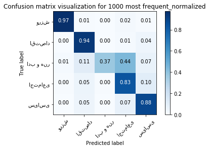

```python
# plt.figure()
# plot_confusion_matrix(first_method_cm, classes=class_name,
#                       title='Confusion matrix visualization for chi squared');
plt.figure()
plot_confusion_matrix(first_method_cm, classes=class_name,
                      title='Confusion matrix visualization for 1000 most frequent_normalized', normalize=True);
plt.show()
```

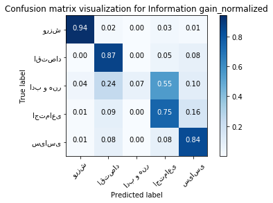

```python
plt.figure()
plot_confusion_matrix(second_method_cm, classes=class_name,
                      title='Confusion matrix visualization for Information gain_normalized', normalize=True);
plt.show()
```

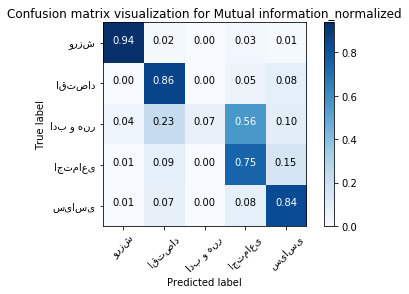

```python
plt.figure()
plot_confusion_matrix(third_method_cm, classes=class_name,
                      title='Confusion matrix visualization for Mutual information_normalized', normalize=True);
plt.show()
```

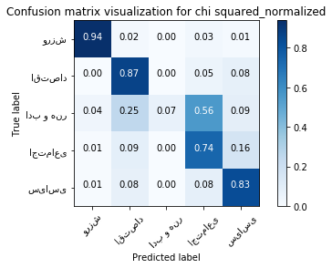

```python
plt.figure()
plot_confusion_matrix(forth_method_cm, classes=class_name,
                      title='Confusion matrix visualization for chi squared_normalized', normalize=True);
plt.show()
```

#### Now we want to test the result for most 100 frequent word vector

```python
number_of_selected_words=100
selected_words= []
for i in range(0, number_of_selected_words):
    selected_words.append(word_frequency_word_pair[i][1])
X_count = np.zeros((number_of_docs, number_of_selected_words), dtype=float)
for i in range(0, number_of_docs):
    for j in range(0, number_of_selected_words):
        tmp_dict= document_dicts[i]
        tmp_word = selected_words[j]
        if tmp_word in tmp_dict:
            X_count[i][j]=tmp_dict[tmp_word]
        else:
            X_count[i][j]=0
```

```python
tmp_sum = np.array([np.sum(X_count, axis=1)])
X = X_count / tmp_sum.T
y = np.asarray(doc_clss_index)
```

```python
from sklearn import svm
clf = svm.LinearSVC()
shuffled_index = np.arange(0, number_of_docs)
np.random.shuffle(shuffled_index)
confusion_matrix_sum = np.zeros((number_of_classes, number_of_classes), dtype=float)
for train_index, test_index in kf.split(X):

    train_index_shuffled = np.take(shuffled_index, train_index)
    test_index_shuffled = np.take(shuffled_index, test_index)
    X_train, X_test = X[train_index_shuffled], X[test_index_shuffled]
    y_train, y_test = y[train_index_shuffled], y[test_index_shuffled]

    clf.fit(X_train, y_train)
    prediction = clf.predict(X_test)

    confusion_matrix_sum += confusion_matrix(y_test, prediction)

confusion_matrix_avg = confusion_matrix_sum / k
```

#### Confusion Matrix for 100 most frequent

```python
first_method_confusion_matrix_100 = confusion_matrix_avg
tmp = 0
for i in range(0, number_of_classes):
    tmp += confusion_matrix_avg[i][i]
first_method_accuracy_100= (tmp*k)/ number_of_docs
```

```python
print ("accuracy:", first_method_accuracy_100,'\n')
print ("confusion matrix:\n")
first_method_cm_100 = confusion_matrix_avg
pd.DataFrame(first_method_cm_100)
```

```
accuracy: 0.803953488372093

confusion matrix:
```

|  | 0 | 1 | 2 | 3 | 4 |
| --- | --- | --- | --- | --- | --- |
| 0 | 375.6 | 8.2 | 0.0 | 11.4 | 4.8 |
| 1 | 1.4 | 382.4 | 0.4 | 22.0 | 33.8 |
| 2 | 3.2 | 24.8 | 7.2 | 55.2 | 9.6 |
| 3 | 1.8 | 30.8 | 1.0 | 267.4 | 59.0 |
| 4 | 2.4 | 32.6 | 0.2 | 34.6 | 350.2 |

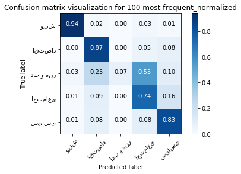

```python
plt.figure()
plot_confusion_matrix(first_method_confusion_matrix_100, classes=class_name,
                      title='Confusion matrix visualization for 100 most frequent_normalized', normalize=True);
plt.show()
```